# Playing Bowling with Proximal Policy Optimization (PPO)

This notebook has been created by Alessandro Pomponio for the Autonomous and Adaptive System course, held by prof. Mirco Musolesi at the University of Bologna.

## Install prerequisites

Since this notebook was written on Google Colab, we need to install some prerequisites if we want to render outputs.

```python
!(apt update && apt install xvfb ffmpeg python-opengl -y) > /dev/null 2>&1
!pip install gym-notebook-wrapper > /dev/null 2>&1
!pip install opencv-python > /dev/null 2>&1
!pip install gym[atari] > /dev/null 2>&1
```

```python
import tensorflow as tf
import numpy as np
import cv2 as cv
import gnwrapper
import time
import gym

from tensorflow.keras import backend as K
from tensorflow.keras.layers import Input, Conv2D, Flatten, Dense
from tensorflow.keras.losses import MeanSquaredError
from tensorflow.keras.models import Sequential
from tensorflow.keras.optimizers import Adam
from tensorflow.keras import Model
from tensorflow import keras
from scipy.stats import entropy
```

## Analyzing the environment

We start by taking a look at how the `Bowling` environment is set up and implemented in OpenAI Gym.

References:

- https://gym.openai.com/envs/Bowling-v0/
- https://github.com/openai/gym/blob/master/gym/envs/atari/atari_env.py

```python
ENVIRONMENT='Bowling-v0'
env = gym.make(ENVIRONMENT)
```

The observation space is given by the video feed, an 8-bit 210x160 RGB image (with values in the range 0-255)

```python
print(env.observation_space)
```

```
Box(0, 255, (210, 160, 3), uint8)
```

We can perform 6 actions:

```python
print(env.action_space)
```

```
Discrete(6)
```

The actions have the following meanings:

```python
env.unwrapped.get_action_meanings()
```

```
['NOOP', 'FIRE', 'UP', 'DOWN', 'UPFIRE', 'DOWNFIRE']
```

## Setting up the environment

Reading the report ["Game Playing with Deep Q-Learning using OpenAI Gym"](http://cs231n.stanford.edu/reports/2017/pdfs/616.pdf) by Robert Chuchro and Deepak Gupta we find a few suggestions that can help us in preprocessing the observations provided by the environment.

From the report:

- *First, we convert the image to gray scale.*
- *Next, we de-noise the image using adaptive thresholding.*
- *Afterwards, we normalize values to be between 0 and 1.*
- [...] *and reduce the image to 80x80 pixels.*
- *Finally, we stack last 4 frames as input to network to form the 80x80x4 input to the network.*

In addition to what has been done in the paper, we can try to crop the observation to include only the bowling lane. This might be able to further optimize the training, making the network only focus on what is important.

We will implement all these preprocessing actions as `gym.ObservationWrapper`, following the templates shown in [Alexander Van de Kleut's blog](https://alexandervandekleut.github.io/gym-wrappers/) and in the [official OpenAI Gym repository](https://github.com/openai/gym/tree/master/gym/wrappers).

### Cropping the observation

We will start by cropping the observation, as we must figure out what to do on our own.

To make this process more "visual", we will import matplotlib and use it to show the observation in the notebook. We will render the environment as a `rgb_array` to allow for plotting.

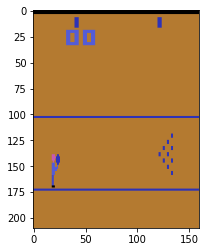

```python
%matplotlib inline
import matplotlib.pyplot as plt
env.reset()
obs = env.render(mode = "rgb_array")
plt.imshow(obs)
```

A first look at the picture tells us that the bowling lane starts a little after 100 pixels and ends a little before 175 pixels (vertically). After some testing (running the game and rendering frames), we are able to crop the observation vertically with the following values:

```python
vertical_crop_start   = 105       # @param{type:"integer"}
vertical_crop_end     = 170       # @param{type:"integer"}
horizontal_crop_start = 0         # @param{type:"integer"}
horizontal_crop_end   = 160       # @param{type:"integer"}
```

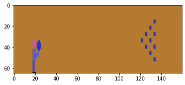

```python
cropped_obs = obs[vertical_crop_start:vertical_crop_end, horizontal_crop_start:horizontal_crop_end]
plt.imshow(cropped_obs)
```

This has reduced the observation from (210, 160, 3) to (65, 160, 3), decreasing the screen size by ~70%.

```python
cropped_obs.shape
```

```
(65, 160, 3)
```

We then define our wrapper:

```python
class CropObservation(gym.ObservationWrapper):

    def __init__(self, env):
        super().__init__(env)

    def observation(self, obs):
        return obs[vertical_crop_start:vertical_crop_end,\
                   horizontal_crop_start:horizontal_crop_end]
```

### Converting the observation to greyscale

This functionality is part of the predefined wrappers in OpenAI Gym. We will then use the `GreyScaleObservation` wrapper, which can be found here: https://github.com/openai/gym/blob/master/gym/wrappers/gray_scale_observation.py

### Denoising the observation - Adaptive Gaussian Thresholding

This type of denoising may or may not be useful in our case, as the environment does not have any type of background noise. We will implement it as a wrapper anyway, using OpenCV's function: https://docs.opencv.org/3.4/d7/d4d/tutorial_py_thresholding.html

```python
class DenoiseObservation(gym.ObservationWrapper):

    def __init__(self, env):
        super().__init__(env)

    def observation(self, obs):
        return cv.adaptiveThreshold(obs, 255, cv.ADAPTIVE_THRESH_GAUSSIAN_C, cv.THRESH_BINARY, 3, 2)
```

### Normalizing the observation

We know that the state is represented by 8-bit values, from 0 to 255. To normalize it, we simply divide the observation by 255.

```python
class NormalizeObservation(gym.ObservationWrapper):

    def __init__(self, env):
        super().__init__(env)

    def observation(self, obs):
        return np.divide(obs, 255.)
```

### Resizing the observation

In the original paper, the authors shrunk the observation from the original size down to 80x80. Since we can crop the observation by 70%, we might want to further reduce this size.

Again, this feature is pre-packed in OpenAI Gym, in the `ResizeObservation` wrapper, which can be found here: https://github.com/openai/gym/blob/master/gym/wrappers/resize_observation.py

### Stacking frames

To stack frames, we will use another one of the provided wrappers in Gym, `FrameStack`, which can be found here: https://github.com/openai/gym/blob/master/gym/wrappers/frame_stack.py

### Preprocessing settings

For ease of use, we condense here all the preprocessing settings:

```python
# Cropping
use_cropping            = True        # @param {type:"boolean"}

# Greyscale
use_greyscale           = True        # @param {type:"boolean"}

# Denoiser
use_denoiser            = True        # @param {type:"boolean"}

# Frame stacking
stack_frames            = True        # @param {type:"boolean"}
frame_stack_size        = 4           # @param {type:"integer"}

# Normalization
use_normalization       = True        # @param {type:"boolean"}

# Resizing
resize_observation      = True        # @param {type:"boolean"}
observation_side_length = 80          # @param {type:"integer"}
```

### Preprocessing results

Finally, let us look at the results of our preprocessing:

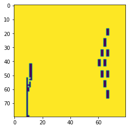

```python
cropped_obs = obs[vertical_crop_start:vertical_crop_end, horizontal_crop_start:horizontal_crop_end]
cropped_obs = cv.resize(cropped_obs, (80,80), interpolation = cv.INTER_AREA)
cropped_obs = cv.cvtColor(cropped_obs, cv.COLOR_RGB2GRAY)
cropped_obs = cv.adaptiveThreshold(cropped_obs, 255, cv.ADAPTIVE_THRESH_GAUSSIAN_C, cv.THRESH_BINARY, 3, 2)
cropped_obs = cropped_obs / 255.
plt.imshow(cropped_obs)
```

Note that in the end we ended up keeping the image resolution at 80x80. This was done because at lower resolutions (such as 50x50), pin and ball dimensions and shapes were being heavily altered, as we can see in the picture below:

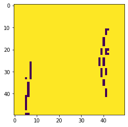

```python
cropped_obs = obs[vertical_crop_start:vertical_crop_end, horizontal_crop_start:horizontal_crop_end]
cropped_obs = cv.resize(cropped_obs, (50, 50), interpolation = cv.INTER_AREA)
cropped_obs = cv.cvtColor(cropped_obs, cv.COLOR_RGB2GRAY)
cropped_obs = cv.adaptiveThreshold(cropped_obs, 255, cv.ADAPTIVE_THRESH_GAUSSIAN_C, cv.THRESH_BINARY, 3, 2)
cropped_obs = cropped_obs / 255.
plt.imshow(cropped_obs)
```

### Get environment function

We also create a utility function to create the environment given the settings above. They have been re-ordered to make sure everything works as expected.

```python
def get_environment():

  env = gym.make(ENVIRONMENT)

  if use_cropping:
    env = CropObservation(env)
  if use_greyscale:
    env = gym.wrappers.GrayScaleObservation(env)
  if use_denoiser:
    env = DenoiseObservation(env)
  if use_normalization:
    env = NormalizeObservation(env)
  if resize_observation:
    env = gym.wrappers.ResizeObservation(env, (observation_side_length, observation_side_length))
  if stack_frames and frame_stack_size > 0:
    env = gym.wrappers.FrameStack(env, frame_stack_size)

  return env
```

## Proximal Policy Optimization

From ["Proximal Policy Optimization Algorithms"](https://arxiv.org/abs/1707.06347v2) by Schulman et al:

[Proximal Policy Optimization algorithms are] *a new family of policy gradient methods [...] which alternate between sampling data through interaction with the environment, and optimizing a "surrogate" objective function using stochastic gradient ascent.* [They] *have some of the benefits of trust region policy optimization (TRPO) but they are much simpler to implement, more general, and have better sample complexity (empirically).*

This family of algorithms has been proposed due to the lack of simple, efficient, scalable and robust policy gradient algorithms for reinforcement learning. At that time, in fact, the most common algorithms used were *Q*-learning (which struggled in problems with continuous action spaces, and was generally poorly understood) and Trust Region Policy Optimization (which is complicated and not compatible with architectures that include noise or parameter sharing).

PPO attempts to achieve the same data efficiency and reliable performance of TRPO, while using only first-order optimization. This is achieved by means of *a novel objective with clipped probability ratios, which forms a pessimistic estimate (i.e., a lower bound) of the performance of the policy.* Policy optimization is obtained by alternating *between sampling data from the policy and performing several epochs of optimization on the sampled data.*

### Hyperparameters

We will use the hyperparameters suggested for Atari games in the paper. Note that the Adam stepize and the clipping parameter $\epsilon$ are multiplied by a value $\alpha$, which is linearly annealed from 1 to 0 over the course of learning.

In addition, for the sake of simplicity, we will write a PPO implementation that uses only one actor (the paper uses 8 in parallel in Atari experiments)

```python
horizon             = 128                 # @param{type:"integer"}
adam_stepsize       = 2.5e-4              # @param{type:"number"}
num_epochs          = 3                   # @param{type:"integer"}
minibatch_size      = 32                  # @param{type:"integer"}
gamma               = 0.99                # @param{type:"number"}
gae_lambda          = 0.95                # @param{type:"number"}
clipping_parameter  = 0.1                 # @param{type:"number"}
c1_coeff            = 1                   # @param{type:"integer"}
c2_coeff            = 0.01                # @param{type:"number"}

# We define epsilon here so we can use it as a global variable and
# modify it later on by multiplying it by alpha
epsilon = clipping_parameter
```

### Clipped Surrogate Objective

In order to limit the size of the policy update, TRPO applies a constraint $\beta$ to a "surrogate" objective function based on the KL-divercence between the old and the new policy.

In theory TRPO should use a penalty instead of a hard constraint; choosing a value of $\beta$ that performs well across different problems, however, is very difficult. The authors of PPO, then took TRPO's surrogate objective:

$L^{CPI}(\theta) = \hat{\mathbb{E}}_t \Big[\frac{\pi_{\theta}(a_t \vert s_t)}{\pi_{\theta_{old}}(a_t \vert s_t)} \hat{A}_t \Big] = \hat{\mathbb{E}}_t \Big[ r_t(\theta) \hat{A}_t \Big]$

and modified it to penalize changes to the policy that move $r_t (\theta)$ away from 1 (as it would lead to an excessively large policy update without constraints). They propose the following:

$L^{CLIP}(\theta)=\hat{\mathbb{E}}_t \bigg[\min\left(r_t(\theta)\hat{A}_t, clip\left(r_t(\theta), 1-\epsilon, 1+\epsilon \right) \hat{A}_t\right)\bigg]$

This new objective clips the probability ratio to remove the incentive for moving $r_t$ outside the interval around 1 delimited by $\epsilon$ and returns the minimum between the unclipped and the clipped objective, effectively acting as a lower bound. In practice, this leads to ignoring the change in probability ratio when it would make the objective improve, only including it when it makes it worse.

```python
def clipped_surrogate_objective(probability_ratio, advantages):
  unclipped_objectives =  probability_ratio * advantages
  clipped_objectives = K.clip(probability_ratio, 1 - epsilon, 1 + epsilon) * advantages
  lower_bounds = K.min([unclipped_objectives, clipped_objectives], axis = 0)
  return K.mean(lower_bounds)
```

### Advantages

The term $\hat{A}_t$ that we saw in the previous formulas is an advantage estimator, a quantity showing how good or bad something is compared to our current estimates.

The authors of this paper propose a truncated version of generalized advantage estimation, adapting what was proposed in ["Asynchronous methods for deep reinforcement learning"](https://dl.acm.org/doi/10.5555/3045390.3045594) by Mnih et al.

$\hat{A}_t = \delta_t + (\gamma\lambda)\delta_{t+1} + \dots + \dots + (\gamma\lambda)^{T-t+1}\delta_{T-1}$

where $\delta_t = r_t + \gamma V(s_{t+1}) - V(s_t)$

Note: the formula above does not explicitly put a check on whether the state at $t+1$ is a terminal state or not.

```python
def compute_A_t(rewards, values, dones, start, T):

  A_t = rewards[start] - values[start]
  coefficient = 1

  for t in range(start + 1, T - 1):
    delta = rewards[t] + (gamma * (1 - dones[t + 1]) * values[t + 1]) - values[t]
    A_t += coefficient * delta
    coefficient = (gamma * gae_lambda)**(T - t + 1)

  return A_t

def compute_advantage_estimates(rewards, values, dones, T):

  advantage_estimates = []

  for t in range(T):
    A_t = compute_A_t(rewards, values, dones, t, T)
    advantage_estimates.append(A_t)

  return np.array(advantage_estimates)
```

Since we will have to compute the discounted returns as well, we will create a function for it, too:

```python
def compute_discounted_returns(rewards, dones, T):

    returns = []
    discounted_sum = 0

    for t in reversed(range(T)):
        discounted_sum = (1 - dones[t]) * rewards[t] + gamma * discounted_sum
        returns.insert(0, discounted_sum)

    return returns
```

### Loss function

We will be using a neural network architecture that shares parameters between the policy and the value function; this requires us to *use a loss function that combines the policy surrogate and a value function error term. This objective can further be augmented by adding an entropy bonus to ensure sufficient exploration.*

*Combining these terms, we obtain the following objective, which is (approximately) maximized each iteration:*

$L_t^{CLIP+VF+S}(\theta) = \hat{\mathbb{E}} \big[L_t^{CLIP}(\theta) - c_1 L_t^{VF}(\theta) + c_2 S[\pi_{\theta}](s_t) \big]$

_where $c_1$, $c_2$ are coefficients, and $S$ denotes an entropy bonus, and $L_t^{VF}$ is a squared-error loss $\left( V_{\theta}(s_t) - V_t^{targ} \right)^2$._

```python
def compute_total_loss(actor_loss, critic_loss, entropy_bonus):
  total_loss = actor_loss - (c1_coeff * critic_loss) + (c2_coeff * entropy_bonus)
  return K.mean(total_loss)
```

### Algorithm

The authors provide a pseudocode implementation of PPO with fixed-length trajectory segments:

```
for iteration = 1, 2, ... do
  for actor = 1, 2, ..., N do
    Run policy \pi_{\theta_{old}} in environment for T timesteps
    Compute advantage estimates \hat{A}_1, ..., \hat{A}_T
  end for
  Optimize surrogate L wrt \theta, with K epochs and minibatch size M \le NT
  \theta_{old} <- \theta
end for
```

We will first define the neural network we will use as function approximator and a few utility functions to run part of the algorithm.

### Neural network model

For the neural network we will refer to the supplementary material of the paper "Asynchronous Methods for Deep Reinforcement Learning" by Minh et al. available [here](https://proceedings.mlr.press/v48/mniha16-supp.pdf).

The implementation that follows is also inspired by the Keras documentation:

- https://keras.io/examples/rl/actor_critic_cartpole/
- https://keras.io/examples/rl/deep_q_network_breakout/

#### Parameters

We set the network parameters according to our configuration.

```python
screen_height  = 210
screen_width   = 160
color_channels = 3

if use_cropping:
  screen_height  = 165
  screen_width   = 120
if use_greyscale:
  color_channels = 1
if resize_observation:
  screen_height  = observation_side_length
  screen_width   = observation_side_length

if stack_frames and frame_stack_size > 0:
  input_shape = (frame_stack_size, screen_height, screen_width, color_channels)
else:
  input_shape = (screen_height, screen_width, color_channels)

actions_available = env.action_space.n
```

#### Model

We define a utility function to get a new network for ease of use.

```python
def get_network():

  # Input layer
  inputs = Input(shape=input_shape)

  # Convolutions on the frames on the screen
  layer1 = Conv2D(16, 8, strides = 4, activation = "relu")(inputs)
  layer2 = Conv2D(32, 4, strides = 2, activation = "relu")(layer1)

  # Flatten and add densely connected layer
  layer3 = Flatten()(layer2)
  layer4 = Dense(256, activation = "relu")(layer3)

  # Actor and critic layers
  actor = Dense(actions_available, activation = "softmax")(layer4)
  critic = Dense(1, activation = "linear")(layer4)

  return Model(inputs = inputs, outputs = [actor, critic])
```

### Playing for T timesteps

As we said before, PPO runs the policy for $T$ timesteps (where $T$ is much less than the episode length) and uses the collected samples for an update.

Here we define a utility function to play for $T$ timesteps:

```python
# The state is required in input because we must be able to resume the episode
# from where we left off.
def play_for_timestamps(env, state, model):

  states               = []
  actions              = []
  action_probabilities = []
  critic_values        = []
  rewards              = []
  dones                = []

  # The timesteps for which we play is part of our hyperparameters
  # and is represented by the horizon
  for step in range(horizon):

    # We must call expand_dims to have the correct input size for the network
    t_state = tf.expand_dims(state, axis = 0)
    actor_value, critic_value = model(t_state)

    # Normally the action distribution would be (1,6)
    # By squeezing we remove "one-dimensional dimensions"
    # so we get (6,)
    # https://numpy.org/doc/stable/reference/generated/numpy.squeeze.html
    action_probability = np.squeeze(actor_value)
    critic_value = np.squeeze(critic_value)

    action = np.random.choice(actions_available, p = action_probability)
    next_state, reward, done, _ = env.step(action)

    states.append(state)
    actions.append(action)
    action_probabilities.append(action_probability)
    critic_values.append(critic_value)
    rewards.append(reward)
    dones.append(done)

    if done:
      state = env.reset()
    else:
      state = next_state

  return states, actions, action_probabilities, critic_values, rewards, dones
```

### Generating minibatches

The PPO update is run on minibatches of size `minibatch_size`, we create a generator function to output them starting from the data we collected.

```python
def generate_minibatches(states, actions, action_probabilities, critic_values, rewards, dones):

    states               = np.array(states)
    actions              = np.array(actions)
    action_probabilities = np.array(action_probabilities)
    critic_values        = np.array(critic_values)
    rewards              = np.array(rewards)
    dones                = np.array(dones)

    number_of_batches = horizon // minibatch_size
    for batch in range(number_of_batches):
      batch_start = batch * minibatch_size
      batch_end   = (batch + 1) * minibatch_size
      indices = np.arange(batch_start, batch_end)
      yield states[indices], actions[indices], action_probabilities[indices],\
            critic_values[indices], rewards[indices], dones[indices]
```

### PPO update

The PPO update is run on the data obtained while playing and is repeated for `num_epochs`.

```python
def perform_ppo_update(model, states, actions, action_probabilities, critic_values, rewards, dones):
  for epoch in range(num_epochs):
    for states_batch, actions_batch, action_probabilities_batch,\
        critic_values_batch, rewards_batch, dones_batch in \
        generate_minibatches(states, actions, action_probabilities,\
                             critic_values, rewards, dones):
          with tf.GradientTape()	as tape:

            # We need the action probabilities output by the current network
            # for our probability ratios. This is because we repeat this training
            # phase for `num_epochs` and the probabilities will change.
            current_action_probabilities, current_critic_values = model(states_batch)

            # We want the probability ratios only for the actions that we took
            # I could't find a better way to do this via numpy, so I had to resort
            # to this abomination of a list comprehension
            probability_ratios = current_action_probabilities / action_probabilities_batch
            pr = [prob[actions_batch[i]] for i, prob in enumerate(probability_ratios)]

            advantages = compute_advantage_estimates(rewards_batch, critic_values_batch, dones_batch, minibatch_size)
            actor_loss = clipped_surrogate_objective(pr, advantages)

            # We use `expand_dims` in order to have the correct dimensions in
            # output. If we were to call `squeeze` on the critic values we would
            # end up with the "missing gradients" error.
            returns = compute_discounted_returns(rewards_batch, dones_batch, minibatch_size)
            returns = np.expand_dims(returns, axis = 1)
            critic_loss = K.mean(K.square(current_critic_values - returns))

            # Calculate entropy values and bonus
            entropy_values = [entropy(probabilities, axis=0) for probabilities in current_action_probabilities]
            entropy_bonus = K.mean(tf.convert_to_tensor(entropy_values, dtype=np.float32))

            # We negate the total loss since we want to perform gradient ascent
            total_loss = compute_total_loss(actor_loss, critic_loss, entropy_bonus)
            total_loss = -total_loss

          gradients = tape.gradient(total_loss, model.trainable_variables)
          optimizer.apply_gradients(zip(gradients, model.trainable_variables))
```

## Run

After implementing the PPO algorithm, we must now instantiate the network and run the training loop.

### Parameters

We initially set a reward threshold of 50 because it served as a measure of the algorithm working. It is also a value near what the paper obtained before the agent started having a few issues and undoing what it had learned until then.

```python
max_frames       = 40e6                   # @param{type:"number"}
history_length   = 100                    # @param{type:"integer"}

# Stop after reward threshold
stop_when_reward_above_threshold = True   # @param{type:"boolean"}
reward_threshold = 50                     # @param{type:"integer"}

# Stop after a set time
limit_training_time = False               # @param{type:"boolean"}
max_training_time = 28800                 # @param{type:"integer"}
```

```python
get_network().summary()
```

```
Model: "model"
__________________________________________________________________________________________________
Layer (type)                    Output Shape         Param #     Connected to
==================================================================================================
input_1 (InputLayer)            [(None, 4, 80, 80, 1 0
__________________________________________________________________________________________________
conv2d (Conv2D)                 (None, 4, 19, 19, 16 1040        input_1[0][0]
__________________________________________________________________________________________________
conv2d_1 (Conv2D)               (None, 4, 8, 8, 32)  8224        conv2d[0][0]
__________________________________________________________________________________________________
flatten (Flatten)               (None, 8192)         0           conv2d_1[0][0]
__________________________________________________________________________________________________
dense (Dense)                   (None, 256)          2097408     flatten[0][0]
__________________________________________________________________________________________________
dense_1 (Dense)                 (None, 6)            1542        dense[0][0]
__________________________________________________________________________________________________
dense_2 (Dense)                 (None, 1)            257         dense[0][0]
==================================================================================================
Total params: 2,108,471
Trainable params: 2,108,471
Non-trainable params: 0
__________________________________________________________________________________________________
```

### Run and train

```python
%%time
model                  = get_network()
env                    = get_environment()
recent_rewards         = np.zeros(history_length)

total_frames           = 0
current_episode_reward = 0
episodes_solved        = 0
target_reached         = False
start_time             = time.time()


state = env.reset()
try:
  while total_frames < max_frames:

    if stop_when_reward_above_threshold and target_reached:
      print("+++++++++++++ TRAINING STOPPED: WE REACHED THE REWARD THRESHOLD +++++++++++++")
      break

    if limit_training_time and (time.time() - start_time) > max_training_time:
      print("+++++++++++++ TRAINING STOPPED: TIMING CONSTRAINTS +++++++++++++")
      break

    # At every iteration we keep linearly decreasing the value of alpha
    alpha = (max_frames - total_frames) / max_frames
    epsilon = clipping_parameter * alpha
    optimizer = Adam(learning_rate = adam_stepsize * alpha)

    # Run the policy for T timesteps
    states, actions, action_distributions, critic_values, rewards, dones = play_for_timestamps(env, state, model)

    # We want to keep track of how many episodes have ended and their reward
    # We shouldn't be in the case where multiple episodes have ended within
    # the same horizon, as it's against what was suggested in the paper.
    # However, we may be very unlucky and perform that poorly.
    latest_termination_index = 0
    termination_indexes = np.nonzero(dones)[0]
    for termination_index in termination_indexes:

      current_episode_reward += np.sum(rewards[latest_termination_index : termination_index + 1])
      recent_rewards[episodes_solved % history_length] = current_episode_reward
      mean_reward = np.mean(recent_rewards)
      episodes_solved += 1

      if stop_when_reward_above_threshold and mean_reward >= reward_threshold:
        print(f"Solved after {episodes_solved} episodes. The last episode ended with a reward of {current_episode_reward}, the average reward was {mean_reward:.2f}")
        target_reached = True
        break
      else:
        print(f"Episode {episodes_solved} ended with a reward of {current_episode_reward}, the average reward is {mean_reward:.2f}")

      if episodes_solved % 100 == 0:
        print(f"++++++ We have been running for {total_frames}/{max_frames} frames ++++++")

      current_episode_reward = 0
      latest_termination_index = termination_index

      # Make sure we keep track of the reward even if there is no end state
      # in this batch.
      if len(termination_indexes) == 0:
        current_episode_reward += np.sum(rewards)

      perform_ppo_update(model, states, actions, action_distributions, critic_values, rewards, dones)
      state = states[-1]
      total_frames += horizon

except KeyboardInterrupt:
  print("---------------- TRAINING INTERRUPTED MANUALLY ----------------")
```

```
Episode 1 ended with a reward of 24.0, the average reward is 0.24
Episode 2 ended with a reward of 20.0, the average reward is 0.44
Episode 3 ended with a reward of 27.0, the average reward is 0.71
Episode 4 ended with a reward of 23.0, the average reward is 0.94
Episode 5 ended with a reward of 18.0, the average reward is 1.12
Episode 6 ended with a reward of 24.0, the average reward is 1.36
Episode 7 ended with a reward of 27.0, the average reward is 1.63
Episode 8 ended with a reward of 24.0, the average reward is 1.87
Episode 9 ended with a reward of 31.0, the average reward is 2.18
Episode 10 ended with a reward of 30.0, the average reward is 2.48
Episode 11 ended with a reward of 31.0, the average reward is 2.79
Episode 12 ended with a reward of 21.0, the average reward is 3.00
Episode 13 ended with a reward of 22.0, the average reward is 3.22
Episode 14 ended with a reward of 28.0, the average reward is 3.50
Episode 15 ended with a reward of 27.0, the average reward is 3.77
Episode 16 ended with a reward of 30.0, the average reward is 4.07
Episode 17 ended with a reward of 25.0, the average reward is 4.32
Episode 18 ended with a reward of 28.0, the average reward is 4.60
Episode 19 ended with a reward of 24.0, the average reward is 4.84
Episode 20 ended with a reward of 41.0, the average reward is 5.25
Episode 21 ended with a reward of 24.0, the average reward is 5.49
Episode 22 ended with a reward of 18.0, the average reward is 5.67
Episode 23 ended with a reward of 24.0, the average reward is 5.91
Episode 24 ended with a reward of 23.0, the average reward is 6.14
Episode 25 ended with a reward of 21.0, the average reward is 6.35
Episode 26 ended with a reward of 25.0, the average reward is 6.60
Episode 27 ended with a reward of 22.0, the average reward is 6.82
Episode 28 ended with a reward of 39.0, the average reward is 7.21
Episode 29 ended with a reward of 30.0, the average reward is 7.51
Episode 30 ended with a reward of 33.0, the average reward is 7.84
Episode 31 ended with a reward of 31.0, the average reward is 8.15
Episode 32 ended with a reward of 12.0, the average reward is 8.27
Episode 33 ended with a reward of 21.0, the average reward is 8.48
Episode 34 ended with a reward of 27.0, the average reward is 8.75
Episode 35 ended with a reward of 25.0, the average reward is 9.00
Episode 36 ended with a reward of 29.0, the average reward is 9.29
Episode 37 ended with a reward of 30.0, the average reward is 9.59
Episode 38 ended with a reward of 20.0, the average reward is 9.79
Episode 39 ended with a reward of 29.0, the average reward is 10.08
Episode 40 ended with a reward of 15.0, the average reward is 10.23
```

[output cut: 740 more lines]

```
Episode 774 ended with a reward of 70.0, the average reward is 49.14
Episode 775 ended with a reward of 54.0, the average reward is 49.29
Episode 776 ended with a reward of 44.0, the average reward is 49.25
Episode 777 ended with a reward of 77.0, the average reward is 49.54
Episode 778 ended with a reward of 44.0, the average reward is 49.52
Episode 779 ended with a reward of 62.0, the average reward is 49.60
Episode 780 ended with a reward of 60.0, the average reward is 49.73
Episode 781 ended with a reward of 48.0, the average reward is 49.78
Episode 782 ended with a reward of 59.0, the average reward is 49.92
Episode 783 ended with a reward of 52.0, the average reward is 49.92
Episode 784 ended with a reward of 44.0, the average reward is 49.91
Solved after 785 episodes. The last episode ended with a reward of 52.0, the average reward was 50.04
+++++++++++++ TRAINING STOPPED: WE REACHED THE REWARD THRESHOLD +++++++++++++
CPU times: user 21h 11min 56s, sys: 26min 19s, total: 21h 38min 15s
Wall time: 21h 4min 47s
```

### Iterative improvements

Now that we have reached the target that we had set, we save the model and iteratively try to see how much we can improve before things start to go wrong.

Note: with `#train` we mean the code within the `try/except` statement in the previous cell.

```python
model.save("ppo_bowling.h5")
```

Let us try to improve the average reward from 50 to 60.

```python
target_reached = False
reward_threshold = 60
current_episode_reward = 0

#train
```

```
Episode 786 ended with a reward of 107.0, the average reward is 50.61
Episode 787 ended with a reward of 44.0, the average reward is 50.33
Episode 788 ended with a reward of 52.0, the average reward is 50.45
Episode 789 ended with a reward of 45.0, the average reward is 50.48
Episode 790 ended with a reward of 69.0, the average reward is 50.69
Episode 791 ended with a reward of 77.0, the average reward is 51.14
Episode 792 ended with a reward of 69.0, the average reward is 51.42
Episode 793 ended with a reward of 74.0, the average reward is 51.77
Episode 794 ended with a reward of 48.0, the average reward is 51.81
Episode 795 ended with a reward of 53.0, the average reward is 51.87
Episode 796 ended with a reward of 52.0, the average reward is 51.97
Episode 797 ended with a reward of 59.0, the average reward is 52.12
Episode 798 ended with a reward of 52.0, the average reward is 52.30
Episode 799 ended with a reward of 59.0, the average reward is 52.50
Episode 800 ended with a reward of 48.0, the average reward is 52.54
++++++ We have been running for 2255104/40000000.0 frames ++++++
Episode 801 ended with a reward of 54.0, the average reward is 52.63
Episode 802 ended with a reward of 61.0, the average reward is 52.69
Episode 803 ended with a reward of 42.0, the average reward is 52.75
Episode 804 ended with a reward of 62.0, the average reward is 52.91
Episode 805 ended with a reward of 55.0, the average reward is 52.90
Episode 806 ended with a reward of 66.0, the average reward is 52.68
Episode 807 ended with a reward of 39.0, the average reward is 52.64
Episode 808 ended with a reward of 56.0, the average reward is 52.80
Episode 809 ended with a reward of 62.0, the average reward is 52.87
Episode 810 ended with a reward of 49.0, the average reward is 52.86
Episode 811 ended with a reward of 66.0, the average reward is 52.99
Episode 812 ended with a reward of 53.0, the average reward is 53.00
Episode 813 ended with a reward of 46.0, the average reward is 53.04
Episode 814 ended with a reward of 66.0, the average reward is 53.38
Episode 815 ended with a reward of 57.0, the average reward is 53.48
Episode 816 ended with a reward of 48.0, the average reward is 53.48
Episode 817 ended with a reward of 52.0, the average reward is 53.22
Episode 818 ended with a reward of 68.0, the average reward is 53.65
Episode 819 ended with a reward of 64.0, the average reward is 53.71
Episode 820 ended with a reward of 42.0, the average reward is 53.57
Episode 821 ended with a reward of 62.0, the average reward is 53.66
Episode 822 ended with a reward of 56.0, the average reward is 53.77
Episode 823 ended with a reward of 33.0, the average reward is 53.55
Episode 824 ended with a reward of 59.0, the average reward is 53.64
```

[output cut: 359 more lines]

```
Episode 1181 ended with a reward of 58.0, the average reward is 58.43
Episode 1182 ended with a reward of 60.0, the average reward is 58.44
Episode 1183 ended with a reward of 45.0, the average reward is 58.32
Episode 1184 ended with a reward of 66.0, the average reward is 58.47
Episode 1185 ended with a reward of 77.0, the average reward is 58.64
Episode 1186 ended with a reward of 60.0, the average reward is 58.81
Episode 1187 ended with a reward of 64.0, the average reward is 59.00
Episode 1188 ended with a reward of 72.0, the average reward is 59.35
Episode 1189 ended with a reward of 76.0, the average reward is 59.53
Episode 1190 ended with a reward of 73.0, the average reward is 59.75
Episode 1191 ended with a reward of 65.0, the average reward is 59.81
Episode 1192 ended with a reward of 59.0, the average reward is 59.87
Episode 1193 ended with a reward of 47.0, the average reward is 59.94
Solved after 1194 episodes. The last episode ended with a reward of 73.0, the average reward was 60.07
+++++++++++++ TRAINING STOPPED: WE REACHED THE REWARD THRESHOLD +++++++++++++
```

```python
model.save("ppo_bowling_60.h5")
```

Let us now to reach 65.

```python
target_reached = False
reward_threshold = 65
current_episode_reward = 0

#train
```

```
Episode 1195 ended with a reward of 86.0, the average reward is 60.47
Episode 1196 ended with a reward of 91.0, the average reward is 60.88
Episode 1197 ended with a reward of 75.0, the average reward is 61.18
Episode 1198 ended with a reward of 67.0, the average reward is 61.41
Episode 1199 ended with a reward of 59.0, the average reward is 61.47
Episode 1200 ended with a reward of 61.0, the average reward is 61.59
++++++ We have been running for 3386752/40000000.0 frames ++++++
Episode 1201 ended with a reward of 79.0, the average reward is 61.70
Episode 1202 ended with a reward of 83.0, the average reward is 62.06
Episode 1203 ended with a reward of 60.0, the average reward is 62.21
Episode 1204 ended with a reward of 74.0, the average reward is 62.35
Episode 1205 ended with a reward of 100.0, the average reward is 62.98
Episode 1206 ended with a reward of 59.0, the average reward is 63.01
Episode 1207 ended with a reward of 88.0, the average reward is 63.34
Episode 1208 ended with a reward of 79.0, the average reward is 63.59
Episode 1209 ended with a reward of 109.0, the average reward is 64.17
Episode 1210 ended with a reward of 80.0, the average reward is 64.41
Episode 1211 ended with a reward of 89.0, the average reward is 64.70
Solved after 1212 episodes. The last episode ended with a reward of 86.0, the average reward was 65.10
+++++++++++++ TRAINING STOPPED: WE REACHED THE REWARD THRESHOLD +++++++++++++
```

```python
model.save("ppo_bowling_65.h5")
```

The agent is performing very well, we can now try to reach 70.

```python
target_reached = False
reward_threshold = 70
current_episode_reward = 0

#train
```

```
Episode 1213 ended with a reward of 79.0, the average reward is 65.32
Episode 1214 ended with a reward of 94.0, the average reward is 65.70
Episode 1215 ended with a reward of 85.0, the average reward is 66.05
Episode 1216 ended with a reward of 73.0, the average reward is 66.28
Episode 1217 ended with a reward of 74.0, the average reward is 66.56
Episode 1218 ended with a reward of 106.0, the average reward is 67.16
Episode 1219 ended with a reward of 71.0, the average reward is 67.34
Episode 1220 ended with a reward of 88.0, the average reward is 67.67
Episode 1221 ended with a reward of 86.0, the average reward is 68.14
Episode 1222 ended with a reward of 89.0, the average reward is 68.38
Episode 1223 ended with a reward of 68.0, the average reward is 68.39
Episode 1224 ended with a reward of 82.0, the average reward is 68.66
Episode 1225 ended with a reward of 95.0, the average reward is 69.09
Episode 1226 ended with a reward of 77.0, the average reward is 69.22
Episode 1227 ended with a reward of 70.0, the average reward is 69.24
Episode 1228 ended with a reward of 82.0, the average reward is 69.57
Episode 1229 ended with a reward of 66.0, the average reward is 69.58
Episode 1230 ended with a reward of 72.0, the average reward is 69.68
Episode 1231 ended with a reward of 95.0, the average reward is 69.91
Solved after 1232 episodes. The last episode ended with a reward of 57.0, the average reward was 70.06
+++++++++++++ TRAINING STOPPED: WE REACHED THE REWARD THRESHOLD +++++++++++++
```

```python
model.save("ppo_bowling_70.h5")
```

The training was very quick thanks to the performance of the agent. Let us now try to reach 75.

```python
target_reached = False
reward_threshold = 75
current_episode_reward = 0

#train
```

```
Episode 1233 ended with a reward of 76.0, the average reward is 70.28
Episode 1234 ended with a reward of 76.0, the average reward is 70.50
Episode 1235 ended with a reward of 68.0, the average reward is 70.69
Episode 1236 ended with a reward of 80.0, the average reward is 70.89
Episode 1237 ended with a reward of 73.0, the average reward is 71.22
Episode 1238 ended with a reward of 58.0, the average reward is 71.26
Episode 1239 ended with a reward of 54.0, the average reward is 71.18
Episode 1240 ended with a reward of 62.0, the average reward is 71.18
Episode 1241 ended with a reward of 45.0, the average reward is 71.02
Episode 1242 ended with a reward of 89.0, the average reward is 71.27
Episode 1243 ended with a reward of 97.0, the average reward is 71.66
Episode 1244 ended with a reward of 78.0, the average reward is 71.91
Episode 1245 ended with a reward of 90.0, the average reward is 72.02
Episode 1246 ended with a reward of 86.0, the average reward is 72.22
Episode 1247 ended with a reward of 52.0, the average reward is 72.12
Episode 1248 ended with a reward of 100.0, the average reward is 72.57
Episode 1249 ended with a reward of 53.0, the average reward is 72.61
Episode 1250 ended with a reward of 59.0, the average reward is 72.65
Episode 1251 ended with a reward of 83.0, the average reward is 72.97
Episode 1252 ended with a reward of 106.0, the average reward is 73.62
Episode 1253 ended with a reward of 50.0, the average reward is 73.09
Episode 1254 ended with a reward of 50.0, the average reward is 73.04
Episode 1255 ended with a reward of 76.0, the average reward is 73.27
Episode 1256 ended with a reward of 75.0, the average reward is 73.32
Episode 1257 ended with a reward of 72.0, the average reward is 73.37
Episode 1258 ended with a reward of 77.0, the average reward is 73.51
Episode 1259 ended with a reward of 96.0, the average reward is 73.79
Episode 1260 ended with a reward of 93.0, the average reward is 74.05
Episode 1261 ended with a reward of 66.0, the average reward is 73.97
Episode 1262 ended with a reward of 76.0, the average reward is 74.14
Episode 1263 ended with a reward of 85.0, the average reward is 74.42
Episode 1264 ended with a reward of 87.0, the average reward is 74.52
Episode 1265 ended with a reward of 55.0, the average reward is 74.35
Episode 1266 ended with a reward of 67.0, the average reward is 74.08
Episode 1267 ended with a reward of 80.0, the average reward is 74.08
Episode 1268 ended with a reward of 59.0, the average reward is 73.87
Episode 1269 ended with a reward of 45.0, the average reward is 73.79
Episode 1270 ended with a reward of 56.0, the average reward is 73.72
Episode 1271 ended with a reward of 83.0, the average reward is 73.66
Episode 1272 ended with a reward of 47.0, the average reward is 73.51
```

[output cut: 20 more lines]

```
Episode 1293 ended with a reward of 46.0, the average reward is 66.54
Episode 1294 ended with a reward of 29.0, the average reward is 66.10
Episode 1295 ended with a reward of 22.0, the average reward is 65.46
Episode 1296 ended with a reward of 1.0, the average reward is 64.56
Episode 1297 ended with a reward of 5.0, the average reward is 63.86
Episode 1298 ended with a reward of 0.0, the average reward is 63.19
Episode 1299 ended with a reward of 25.0, the average reward is 62.85
Episode 1300 ended with a reward of 10.0, the average reward is 62.34
++++++ We have been running for 3658112/40000000.0 frames ++++++
Episode 1301 ended with a reward of 10.0, the average reward is 61.65
Episode 1302 ended with a reward of 19.0, the average reward is 61.01
Episode 1303 ended with a reward of 16.0, the average reward is 60.57
Episode 1304 ended with a reward of 16.0, the average reward is 59.99
Episode 1305 ended with a reward of 21.0, the average reward is 59.20
---------------- TRAINING INTERRUPTED MANUALLY ----------------
```

## Conclusions

Unfortunately, we have hit a wall. Since the training has gone on for almost two days and we had previously reached a good level of performance, we can be happy of the result and see how well the agent performs by making it play a few episodes loading the previous model.

```python
model = keras.models.load_model('ppo_bowling_70.h5')
```

```
WARNING:tensorflow:No training configuration found in the save file, so the model was *not* compiled. Compile it manually.
```

```python
def play_episode(id):

  # We need to have a different path for each run, or we
  # would need to pass `force = True`, but this causes
  # a few issues with the output on Colab
  env = gnwrapper.Monitor(get_environment(), f"./bowling_{id}")
  state = env.reset()
  total_reward = 0
  done = False

  while not done:
    t_state = tf.expand_dims(state, axis = 0)
    actor_value, _ = model(t_state)
    action_probability = np.squeeze(actor_value)
    action = np.random.choice(6, p = action_probability)
    state, reward, done, _ = env.step(action)
    total_reward += reward

  print("The episode ended with a total reward of ", total_reward)
  env.display()
```

```python
for e in range(10):
  play_episode(e)
```

```
The episode ended with a total reward of  61.0
```

```
'openaigym.video.0.1673.video000000.mp4'
```

[video not shown]

```
The episode ended with a total reward of  83.0
```

```
'openaigym.video.1.1673.video000000.mp4'
```

[video not shown]

```
The episode ended with a total reward of  99.0
```

```
'openaigym.video.2.1673.video000000.mp4'
```

[video not shown]

```
The episode ended with a total reward of  76.0
```

```
'openaigym.video.3.1673.video000000.mp4'
```

[video not shown]

```
The episode ended with a total reward of  80.0
```

```
'openaigym.video.4.1673.video000000.mp4'
```

[video not shown]

```
The episode ended with a total reward of  82.0
```

```
'openaigym.video.5.1673.video000000.mp4'
```

[video not shown]

```
The episode ended with a total reward of  72.0
```

```
'openaigym.video.6.1673.video000000.mp4'
```

[video not shown]

```
The episode ended with a total reward of  78.0
```

```
'openaigym.video.7.1673.video000000.mp4'
```

[video not shown]

```
The episode ended with a total reward of  111.0
```

```
'openaigym.video.8.1673.video000000.mp4'
```

[video not shown]

```
The episode ended with a total reward of  82.0
```

```
'openaigym.video.9.1673.video000000.mp4'
```

[video not shown]

The agent plays pretty well, apart from certain instances where it does not even seem to try to hit the pins.

In the future, it may be worth to try and modify the reward function so that it penalizes the agent for the number of pins left standing after each throw, so that it attempts to hit a strike every time. Additionally, it might be beneficial to end the episode after a strike or after the second throw. This could help reduce the learning curve and make the agent focus on every single throw.

## References and inspirations

This work was based on and inspired by:

- [Proximal Policy Optimization Algorithms, Schulman et al., 2017](https://arxiv.org/abs/1707.0634)
- [Asynchronous methods for deep reinforcement learning, Mnih et al., 2016](https://dl.acm.org/doi/10.5555/3045390.3045594)
- [Game Playing with Deep Q-Learning using OpenAI Gym, Chuchro and Gupta, 2017](http://cs231n.stanford.edu/reports/2017/pdfs/616.pdf)
- [Alexander Van de Kleut's blog post on OpenAI Gym wrappers](https://alexandervandekleut.github.io/gym-wrappers/)
- [Arxiv Insight's YouTube video on PPO](https://www.youtube.com/watch?v=5P7I-xPq8u8)
- [DeepGamingAI's YouTube video on PPO](https://www.youtube.com/watch?v=SWllbdcrKLI)
- [Machine Learning With Phil's YouTube video on PPO](https://www.youtube.com/watch?v=hlv79rcHws0)

Inspirations taken from the official documentations for OpenAI Gym, Keras, Numpy, OpenCV, etc. are linked in the code or right before.